# Developing Patterns

```r
library("gridpattern")
```

## Developing Patterns - overview

To develop a pattern for use with `{gridpattern}` (and packages that use it such as `{ggpattern}`) you will need to:

1. Decide whether this is a geometry-based pattern or an array-based pattern.
2. Create a function with the required arguments and return value
3. Use `options()` to let `{gridpattern}` know that a certain pattern name should be delegated to your function.

This vignette shows how to:

- write a `create_pattern()` function of the correct signature for a geometry-based pattern or array-based pattern
- Instruct `{gridpattern}` on where to find this user-defined pattern

## Pattern Classification - geometry-based and array-based

There are only 2 high-level classes of pattern supported by `gridpattern` - geometry-based and array-based.

**Geometry-based** patterns create a series of geometry objects and trim them (using `sf::st_intersection()`, `gridGeometry::polyclipGrob()`, `gridpattern::clippingPathGrob()`, etc) to be within the boundary of the grob. For example, the ‘stripes’ pattern in `gridpattern` is a series of equally spaced rectangular polygons.

**Array-based** patterns are RGBA image arrays. Any supplied image will be processed by `gridpattern` to ensure it is masked to only apply to the area within the grob’s boundary.

## `{ggpattern}` Aesthetics - Descriptions and Defaults

Although custom `{gridpattern}` pattern parameters need not limit itself to the set of aesthetics provided by `{ggpattern}` doing so may make your pattern more useful for others:

**`{ggpattern}` aesthetic summary - click to open/close**

| aesthetic | description | default | possible values |
| --- | --- | --- | --- |
| `pattern` | Name of the pattern to draw | ‘stripe’ | `gridpattern::names_pattern` |
| `pattern_alpha` | Alpha | 1 | value in range [0, 1] or `NA` |
| `pattern_angle` | Rotation angle (entire pattern) | 30 | angle in degrees |
| `pattern_aspect_ratio` | Aspect ratio adjustment | NA | usual range [0.01, 10] |
| `pattern_colour` | Stroke colour | ‘grey20’ | colour |
| `pattern_density` | Approx. fraction of area the pattern fills | 0.2 | value in range [0, 1] |
| `pattern_filename` | Image filename/URL | ’’ | Filename/URL |
| `pattern_fill2` | Second fill colour | ‘#4169E1’ | colour |
| `pattern_fill` | Fill colour | ‘grey80’ | colour |
| `pattern_filter` | Image scaling filter | ‘lanczos’ | `magick::filter_types` |
| `pattern_frequency` | Frequency | 0.1 |  |
| `pattern_gravity` | Image placement | ‘center’ | `magick::gravity_types` |
| `pattern_grid` | Pattern grid type | ‘square’ | ‘square’, ‘hex’, ‘hex_circle’ |
| `pattern_key_scale_factor` | Scale factor for pattern in legend | 1 |  |
| `pattern_linetype` | Stroke linetype | 1 | linetype |
| `pattern_linewidth` | Stroke linewidth | 1 | linewidth |
| `pattern_option_1 - 5` | Generic options for expansion | 0 |  |
| `pattern_orientation` | Orientation | ‘vertical’ | ‘vertical’, ‘horizontal’, ‘radial’ |
| `pattern_phase` | Phase | 0 |  |
| `pattern_res` | Pattern resolution (pixels per inch) | NA |  |
| `pattern_rot` | Rotation angle (shape within pattern) | 0 | angle in degrees |
| `pattern_scale` | Scale | 1 | Multiplier |
| `pattern_shape` | Plotting shape | 1 | shapes |
| `pattern_size` | Size factor (e.g. fontsize) | 1 | fontsize |
| `pattern_spacing` | Spacing between repetitions of pattern | 0.05 | value in range [0, 1] (snpc units) |
| `pattern_subtype` | Generic control option | NA | pattern-dependent |
| `pattern_type` | Generic control option | NA | pattern-dependent |
| `pattern_xoffset` | Shift pattern along x axis | 0 | value in range [0, 1] (snpc units) |
| `pattern_yoffset` | Shift pattern along y axis | 0 | value in range [0, 1] (snpc units) |

Note `{ggpattern}` may also pass other geom aesthetics of possible interest such as `fill`. Also note that `{ggpattern}` will only pass pattern aesthetics values of length one but if the pattern is called directly by `gridpattern::patternGrob()` then the pattern may be passed pattern parameters of arbitrary length.

## Geometry-based pattern functions - Formal Arguments and Return Values

All geometry-based pattern creation functions must:

1. Have the exact function signature: `function(params, boundary_df, aspect_ratio, legend)`
   - `params` - parameters for the pattern (the aesthetics) e.g `pattern_fill`
   - `boundary_df` - data.frame containing polygon information i.e. The `polygon_df` format.
   - `aspect_ratio` - the best guess that `{gridpattern}` / `{ggpattern}` is able to make as to the aspect ratio of the **viewport** in which this pattern is being rendered.
   - `legend` logical value to indicate whether or not this function is being called to render a key legend or the in-place geom fill.
2. Return a grid grob object. This can be any valid grob including a `grid::grobTree()`. The user should make sure it lies within the boundary represented by `boundary_df` either by clipping with functions like `sf::st_intersection()`, `gridGeometry::polyclipGrob()`, `gridpattern::clippingPathGrob()`, etc. or using bounded grob functions like `gridpattern::patternGrob()` or `grid::polygonGrob()`.

## Array-based pattern functions - Formal Arguments and Return Values

All array-based pattern creation functions must:

1. Have the exact function signature: `function(width, height, params, legend)`
   - `width,height` - dimensions of the bounding box of the geom area
   - `params` - parameters from the geom (the aesthetics) e.g `pattern_fill`
   - `legend` logical value to indicate whether or not this function is being called to render a key legend or the in-place geom fill.
2. Return a 3D array of RGBA values (all values in the range [0, 1]). `gridpattern` itself will mask this image so that it only applies to the area within the grob’s boundary.

## The `polygon_df` data.frame format

The `polygon_df` is a very simple data.frame format to contain polygon values. This is used to pass the coordinates of the geom boundary from the geom to the pattern generating function.

It contains only ‘x’ and ‘y’ columns for the coordinates, and an ‘id’ column used to signify which polygon the coordinates belong to.

The following `polygon_df` data.frame contains 2 polygons:

example data in ‘polygon_df’ format

| x | y | id |
| --- | --- | --- |
| 0 | 0 | 1 |
| 1 | 0 | 1 |
| 1 | 1 | 1 |
| 0 | 1 | 1 |
| 0 | 0 | 2 |
| 2 | 0 | 2 |
| 2 | 1 | 2 |
| 0 | 1 | 2 |

## Associating a function with `{gridpattern}` pattern name

There are two global `option()` values which can be set - one for geometry-based patterns, and the other for array-based patterns.

The global values should point to a named list, where the names are the pattern names you want to use within `{gridpattern}`, and the named values are the actual functions. Note for backwards-compatibility with the original `{ggpattern}` system these options start with `ggpattern` instead of `gridpattern`.

```r
options(ggpattern_array_funcs    = list(your_pattern_name = your_pattern_function))
options(ggpattern_geometry_funcs = list(your_pattern_name = your_pattern_function))
```

Pattern names must be different from any of the builtin patterns included in `{gridpattern}`.

## Example geometry-based pattern #1 (recreate polygon)

All geometry-based pattern creation functions must:

1. Have the exact function signature: `function(params, boundary_df, aspect_ratio, legend)`
   - `params` - parameters from the geom (the aesthetics) e.g `pattern_fill`
   - `boundary_df` - data.frame containing polygon information i.e. The `polygon_df` format.
   - `aspect_ratio` - the best guess that `{gridpattern}` / `{ggpattern}` is able to make as to the aspect ratio of the **viewport** in which this pattern is being rendered.
   - `legend` logical value to indicate whether or not this function is being called to render a key legend or the in-place geom fill.
2. Return a grid grob bounded by the boundary represented by `boundary_df` (including grid structures like a `grid::grobTree()`).

For this example we’ll create a simple single color fill pattern based on `grid::polygonGrob()` called ‘polygon’.

```r
create_pattern_polygon <- function(params, boundary_df, aspect_ratio, legend = FALSE) {
    x <- boundary_df$x
    y <- boundary_df$y
    id <- boundary_df$id

    alpha <- ifelse(is.na(params$pattern_alpha), 1, params$pattern_alpha)
    gp <- grid::gpar(alpha = alpha,
                     col = params$pattern_colour,
                     fill = params$pattern_fill,
                     lty = params$pattern_linetype,
                     lwd = params$pattern_linewidth)

    grid::polygonGrob(x = x, y = y, id = id, default.units = "npc", gp = gp)
}
```

A global option `ggpattern_geometry_funcs` is a named list which contains geometry-based pattern creating functions to use outside of `ggpattern`.

The **name** used in this list corresponds to the `pattern` name used with the geom - in this case we will be using `pattern = 'polygon'`.

```r
options(ggpattern_geometry_funcs = list(polygon = create_pattern_polygon))
```

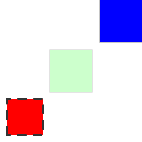

```r
grid.pattern("polygon", fill = "red", size = 4, linetype = "dashed",
             x = c(0.05, 0.05, 0.305, 0.305), y = c(0.05, 0.305, 0.305, 0.05))
grid.pattern("polygon", fill = "green", alpha = 0.2,
             x = c(0.35, 0.35, 0.65, 0.65), y = c(0.35, 0.65, 0.65, 0.35))
grid.pattern("polygon", fill = "blue", colour = "grey",
             x = c(0.7, 0.7, 1.0, 1.0), y = c(0.7, 1.0, 1.0, 0.7))
```

## Example geometry-based pattern function #2 (using other patterns)

All geometry-based pattern creation functions must:

1. Have the exact function signature: `function(params, boundary_df, aspect_ratio, legend)`
   - `params` - parameters from the geom (the aesthetics) e.g `pattern_fill`
   - `boundary_df` - data.frame containing polygon information i.e. The `polygon_df` format.
   - `aspect_ratio` - the best guess that `{gridpattern}` / `{ggpattern}` is able to make as to the aspect ratio of the **viewport** in which this pattern is being rendered.
   - `legend` logical value to indicate whether or not this function is being called to render a key legend or the in-place geom fill.
2. Return a grid grob bounded by the boundary represented by `boundary_df` (including grid structures like a `grid::grobTree()`).

For this example we’ll create an example that re-uses the pre-existing ‘stripe’, ‘circle’, and ‘gradient’ patterns and combines them into a new ‘complex’ pattern.

```r
create_pattern_complex <- function(params, boundary_df, aspect_ratio, legend = FALSE) {
    args <- as.list(params)
    args <- args[grep("^pattern_", names(args))]
    args$x <- boundary_df$x
    args$y <- boundary_df$y
    args$id <- boundary_df$id
    args$prefix <- ""

    args_stripe <- args
    args_stripe$pattern <- "stripe"
    args_stripe$pattern_density <- 0.5 * args$pattern_density
    args_stripe$pattern_spacing <- 2 * args$pattern_spacing
    grob_stripe <- do.call(gridpattern::patternGrob, args_stripe)

    args_circle <- args
    args_circle$pattern <- "regular_polygon"
    args_circle$pattern_shape <- c("circle", "null")
    args_circle$pattern_yoffset <- args$pattern_spacing + args$pattern_yoffset
    args_circle$pattern_type = "horizontal"
    grob_circle <- do.call(gridpattern::patternGrob, args_circle)

    args_gradient <- args
    args_gradient$pattern <- "gradient"
    args_gradient$pattern_fill <- "#00000070"
    args_gradient$pattern_fill2 <- "#FFFFFF70"
    args_gradient$pattern_orientation <- "vertical"
    grob_gradient <- do.call(gridpattern::patternGrob, args_gradient)

    grid::grobTree(grob_stripe, grob_circle, grob_gradient)
}
```

A global option `ggpattern_geometry_funcs` is a named list which contains geometry-based pattern creating functions to use outside of `ggpattern`.

The **name** used in this list corresponds to the `pattern` name used with the geom - in this case we will be using `pattern = 'complex'`.

```r
options(ggpattern_geometry_funcs = list(complex = create_pattern_complex))
```

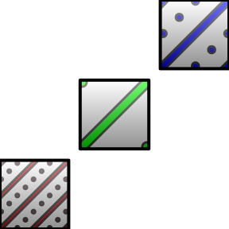

```r
grid.pattern("complex", fill = "red", angle = 45, spacing = 0.05, density = 0.3,
             x = c(0.0, 0.0, 0.3, 0.3), y = c(0.0, 0.3, 0.3, 0.0))
grid.pattern("complex", fill = "green", angle = 45, spacing = 0.2, density = 0.2,
             x = c(0.35, 0.35, 0.65, 0.65), y = c(0.35, 0.65, 0.65, 0.35))
grid.pattern("complex", fill = "blue", angle = 45, spacing = 0.1, density = 0.3,
             x = c(0.7, 0.7, 1.0, 1.0), y = c(0.7, 1.0, 1.0, 0.7))
grid::grid.polygon(x = c(0.0, 0.0, 0.3, 0.3, 0.35, 0.35, 0.65, 0.65, 0.7, 0.7, 1.0, 1.0),
                   y = c(0.0, 0.3, 0.3, 0.0, 0.35, 0.65, 0.65, 0.35, 0.7, 1.0, 1.0, 0.7),
                   id = rep(1:3, each = 4),
                   gp = grid::gpar(col = "black", fill = NA, lwd=4))
```

## Example array-based pattern function

All array-based pattern creation functions must:

1. Have the exact function signature: `function(width, height, params, legend)`
   - `width,height` - dimensions of the bounding box of the geom area
   - `params` - parameters from the geom (the aesthetics) e.g `pattern_fill`
   - `legend` logical value to indicate whether or not this function is being called to render a key legend or the in-place geom fill.
2. Return a 3D array of RGBA values (all values in the range [0, 1]).

For this example we’ll create a simple example that cycles through RGBA values.

Parameters for this pattern:

- `pattern_type` is used to distinguish between source data for the pattern

**Note**: This pattern exploits vector recyling in the creation of the RGBA array, and as dimensions change the alignment of the R, G, B and A planes will not remain in a fixed relationship. Thus if you change the shape of the rendered image, you will change the nature of the pattern.

```r
create_pattern_simple <- function(width, height, params, legend) {

  # Ensure the selected pattern is sane.
  choice <- params$pattern_type
  if (is.null(choice) || is.na(choice) || !is.character(choice)) {
    choice <- 'a'
  }

  # Choose the values with which to fill the array
  values <- switch(
    choice,
    a = rep(c(0, 1, 0, 1, 1, 0, 0, 1, 1, 1), each = 3),
    b = rep(c(1, 0, 0, 1, 0.5, 0.5, 1, 1, 0, 0, 0, 0, 0, 0.5), each = 7),
    c = rep(seq(0, 1, 0.05), each = 7),
    rep(c(0, 1, 0, 1, 1, 0, 0, 1, 1, 1), each = 3)
  )
  # Create an RGBA array of the requested dimensions
  simple_array <- array(values, dim = c(height, width, 4))

  simple_array
}
```

The **name** used in this list corresponds to the `pattern` name used with the geom - in this case we will be using `pattern = 'simple'`.

```r
options(ggpattern_array_funcs = list(simple = create_pattern_simple))
```

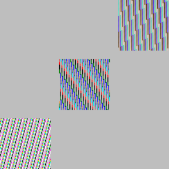

```r
grid::grid.polygon(x = c(0, 0, 1, 1), y = c(0, 1, 1, 0),
                   gp = grid::gpar(col=NA, fill="grey"))
grid.pattern("simple", type = "a",
             x = c(0.0, 0.0, 0.3, 0.3), y = c(0.0, 0.3, 0.3, 0.0))
grid.pattern("simple", type = "b",
             x = c(0.35, 0.35, 0.65, 0.65), y = c(0.35, 0.65, 0.65, 0.35))
grid.pattern("simple", type = "c",
             x = c(0.7, 0.7, 1.0, 1.0), y = c(0.7, 1.0, 1.0, 0.7))
```

## Other examples

The `{ggpattern}` package contains a vignette on developing `{gridpattern}` / `{ggpattern}` patterns with a few more examples: https://coolbutuseless.github.io/package/ggpattern/articles/

Also the `{gridpattern}` source contains the full source code for 21 patterns: https://github.com/trevorld/gridpattern/tree/main/R